# Figure 4: Velocity as a heuristic

Figure 4 links the SMS to Velocity as a heuristic to quantify the female witness effect. This notebook generates Figure 4 and Figure S4 as well as statistics for the results section **Velocity is a unifying feature and heuristic for social modulation**.

```r
library(here)
library(glue)
library(dplyr)
library(tidyr)
library(knitr)
library(pander)
library(scales)
library(nlme)
library(emmeans)
library(ggplot2)
library(ggpubr)
library(ggpmisc)
library(cowplot)
library(effectsize)
library(pwr)
```

```r
source(here('styles.R'))
data_path <- here('data')

SIT_diff <- readRDS(glue('{data_path}/SIT_diff_primary_pcsms.rds'))
SIT_raw <- readRDS(glue('{data_path}/SIT_raw_primary.rds'))
syl_char <- readRDS(glue('{data_path}/SIT_syl_descriptives.rds'))
syl_info <- tibble(read.csv(glue('{data_path}/syllable_info.csv')))
```

### U and D syllables differ in motion and body pose characteristics (Fig. 4a)

We fit an LME model to understand what differentiates up- and downregulated syllabels based on their locomotion characteristics.

```r
# Annotate syl characteristics df with social identity
syl_char$syl_name <- factor(
    syl_info$new_label[match(
        syl_char$syllable,
        substr(syl_info$metric, 4, 6)
    )],
    levels = c(
        "U1", "U2", "N1", "N2", "D1", "D2",
        "D3", "D4", "D5", "D6", "D7", "D8", "D9"
    )
)
syl_char$social_type <- ifelse(grepl("U", syl_char$syl_name), "Up",
    ifelse(grepl("D", syl_char$syl_name), "Down", "No Change")
)

# Avg per social identity type per animal
syl_char %<>%
    filter(social_type != "No Change") %>% # Only interested in U and D
    mutate(id_full = paste(cohort, id)) %>%
    mutate(outcome = ifelse(name %in% c("Velocity", "Distance"), "Motion",
        ifelse(name %in% c("Dist. to Center", "Dist. to Target", "Orientation"),
            "Location", "Pose"
        )
    )) %>% # Group outcome for plotting
    group_by(cohort, id, id_full, name, syl_name, social_type, outcome) %>%
    summarise(mean = mean(mean)) %>% # Avg freq per syllable per animal
    group_by(cohort, id, id_full, name, social_type, outcome) %>%
    summarise(mean = mean(mean)) %>% # Avg freq per social identity per animal
    group_by(name) %>% # ungroup; group by characteristics
    mutate(z_mean = scale(mean)) %>% # scale and center for each characteristic
    na.omit()

# Stats: LME model & EM means contrast
lme_syl_char <- lme(z_mean ~ social_type * name,
    data = syl_char,
    random = ~ 1 | cohort / id
)
lme_syl_char_table <- cbind(
    rownames(summary(lme_syl_char)$tTable),
    round(unname(summary(lme_syl_char)$tTable[, "Value"]), digits = 5),
    round(unname(summary(lme_syl_char)$tTable[, "Std.Error"]), digits = 5),
    round(unname(summary(lme_syl_char)$tTable[, "DF"]), digits = 5),
    round(unname(summary(lme_syl_char)$tTable[, "t-value"]), digits = 5)
)

mm_social <- emmeans(lme_syl_char, ~ social_type | name)
sidak_social_confint <- confint(pairs(mm_social, adjust = "sidak")) # confint and emmeans for plots
tests <- tibble(
    name = sidak_social_confint$name,
    estimate = round(sidak_social_confint$estimate, digits = 5),
    SE = round(sidak_social_confint$SE, digits = 5),
    lower_cl = round(sidak_social_confint$lower.CL, digits = 5),
    upper_cl = round(sidak_social_confint$upper.CL, digits = 5),
    outcome = syl_char$outcome[match(sidak_social_confint$name, syl_char$name)]
)
sidak_social <- summary(pairs(mm_social, adjust = "sidak")) # tratio and p-val for stats
tests$`t-ratio` <- round(sidak_social$t.ratio, digits = 5)
tests$`p-value` <- round(sidak_social$p.value, digits = 5)

em_plot <- ggplot(tests, aes(name, estimate, color = name)) +
    geom_hline(yintercept = 0, color = "gray30") +
    geom_point(size = 3) +
    geom_errorbar(aes(ymin = lower_cl, ymax = upper_cl), width = 0.4, linewidth = 1.1) +
    facet_grid(. ~ outcome, scales = 'free', space = 'free') +
    scale_color_manual(values = c('#030637','#030637','#030637',
                              '#030637','#E95793','#030637','#030637')) + # Color based on direction of effect
    scale_fill_manual(values = c('#030637','#030637','#030637',
                              '#030637','#E95793','#030637','#030637')) + # Color based on direction of effect
    scale_y_continuous(
        breaks = pretty_breaks(), limits = c(-1.5, 2.5),
        name = "Estimated Marginal Mean Difference"
    ) +
    plot_theme +
    theme(
        axis.title.x = element_blank(),
        axis.text.x = element_text(angle = 45, hjust = 1),
        legend.position = "none"
    )
```

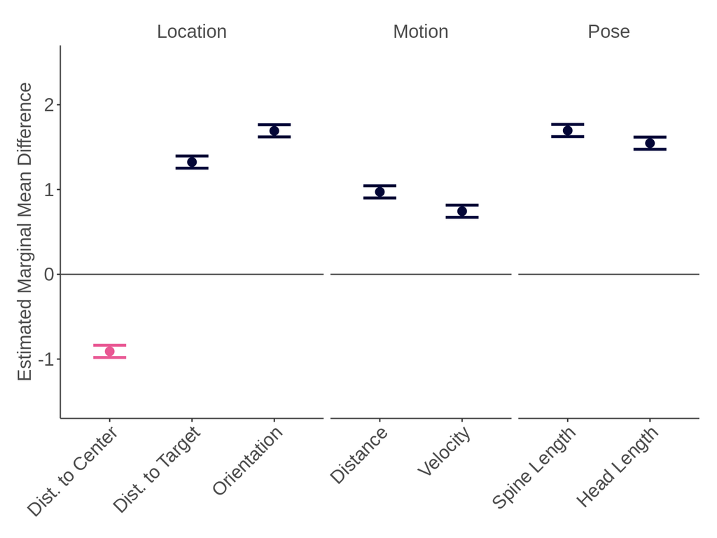

LME Social Identity * name

|  | Value | Std. Error | DF | t-Value |
| --- | --- | --- | --- | --- |
| (Intercept) | 0.48686 | 0.0334 | 10080 | 14.57767 |
| social_typeUp | -0.97219 | 0.03656 | 10080 | -26.58984 |
| nameVelocity | -0.11398 | 0.03656 | 10080 | -3.11754 |
| nameSpine Length | 0.36177 | 0.03656 | 10080 | 9.89466 |
| nameHead Length | 0.28711 | 0.03656 | 10080 | 7.85259 |
| nameDist. to Center | -0.94054 | 0.03656 | 10080 | -25.72422 |
| nameDist. to Target | 0.17594 | 0.03659 | 10080 | 4.80886 |
| nameOrientation | 0.36015 | 0.03659 | 10080 | 9.84371 |
| social_typeUp:nameVelocity | 0.22797 | 0.05171 | 10080 | 4.40887 |
| social_typeUp:nameSpine Length | -0.72354 | 0.05171 | 10080 | -13.99317 |
| social_typeUp:nameHead Length | -0.57422 | 0.05171 | 10080 | -11.10524 |
| social_typeUp:nameDist. to Center | 1.88108 | 0.05171 | 10080 | 36.37954 |
| social_typeUp:nameDist. to Target | -0.3516 | 0.05174 | 10080 | -6.79542 |
| social_typeUp:nameOrientation | -0.72002 | 0.05174 | 10080 | -13.91597 |

Sidak Post-Hoc Contrasts: Down - Up

| name | estimate | SE | lower_cl | upper_cl | outcome | t-ratio | p-value |
| --- | --- | --- | --- | --- | --- | --- | --- |
| Distance | 0.97219 | 0.03656 | 0.90052 | 1.04386 | Motion | 26.58984 | 0 |
| Velocity | 0.74422 | 0.03656 | 0.67255 | 0.81589 | Motion | 20.35477 | 0 |
| Spine Length | 1.69573 | 0.03656 | 1.62406 | 1.76740 | Pose | 46.37917 | 0 |
| Head Length | 1.54641 | 0.03656 | 1.47474 | 1.61808 | Pose | 42.29503 | 0 |
| Dist. to Center | -0.90889 | 0.03656 | -0.98056 | -0.83722 | Location | -24.85860 | 0 |
| Dist. to Target | 1.32378 | 0.03661 | 1.25202 | 1.39555 | Location | 36.15958 | 0 |
| Orientation | 1.69220 | 0.03661 | 1.62044 | 1.76397 | Location | 46.22308 | 0 |

### $\Delta$Velocity correlates with PC2 and the SMS (Fig. 4b)

In line with the observation that locomotion variables differ between up- and downregulated syllables, we observe a strong correlation between PC2 and $\Delta$Velocity as well as between the SMS and $\Delta$Velocity.

```r
PC2 <- ggplot(SIT_diff, aes(PC2, Velocity)) +
  geom_point(aes(color = full_cond), size = 2, alpha = 0.5) +
  stat_poly_line(col = 'black') +
  stat_poly_eq(size = 7, label.y = 'top', label.x = 'right') +
  scale_color_manual(values = col_full) +
  scale_y_continuous(breaks = pretty_breaks(), name = (expression(Delta*' Velocity'))) +
  plot_theme + theme(legend.position = 'none')

SMS <- ggplot(SIT_diff, aes(SMS, Velocity)) +
  geom_point(aes(color = full_cond), size = 2, alpha = 0.5) +
  stat_poly_line(col = 'black') +
  stat_poly_eq(size = 7, label.y = 'bottom', label.x = 'right') +
  scale_color_manual(values = col_full) +
  xlab('SMS') + ylab(expression(Delta*' Velocity')) +
  plot_theme

PC2_cor <- cor.test(SIT_diff$PC2, SIT_diff$Velocity)
SMS_cor <- cor.test(SIT_diff$SMS, SIT_diff$Velocity)
```

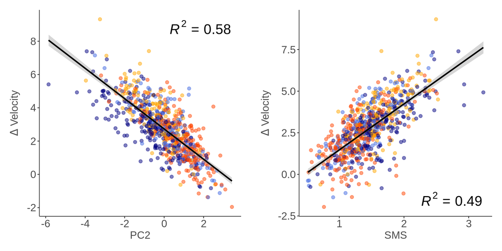

Pearson Correlation tests

|  | statistic | parameter | p.value | estimate |
| --- | --- | --- | --- | --- |
| PC2_cor | c(t = -32.1672523155075) | c(df = 759) | 6.78380930334557e-144 | c(cor = -0.75951293209667) |
| SMS_cor | c(t = 27.1490899526448) | c(df = 759) | 5.91526406782978e-114 | c(cor = 0.701905865285591) |

### $\Delta$Velocity and the SMS detect stress effects equally well (Fig. 4c, 4d)

We visually examine the distributions of the metrics below as well as formally compare effect sizes between the metrics. For males, SI ratio is differentiates best between defeated and control males. In contrast, for females, both SMS and $\Delta$Velocity differentiate between witnesses and controls. While the effect sizes are slightly larger for the SMS, the heuristic $\Delta$Velocity still provides significant improvement in effect size over the SI ratio in females.

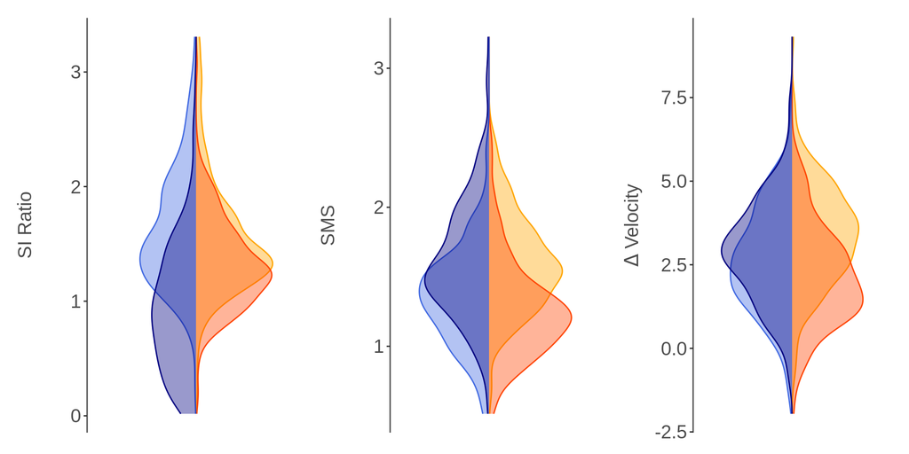

```r
## Distributions Fig. 4c
format <- plot_theme +
          theme(legend.position = 'none',
                axis.line.x = element_blank(),
                axis.text.x = element_blank(),
                axis.title.x = element_blank(),
                axis.ticks.x = element_blank())

SI_distr <- ggplot() +
              geom_density(data = SIT_diff[SIT_diff$Sex == 'Female', ],
                           aes(x = IZ_time, color = full_cond, fill = full_cond),
                           alpha = 0.4) +
              geom_density(data = SIT_diff[SIT_diff$Sex == 'Male', ],
                           aes(x = IZ_time, y = -(..density..), color = full_cond, fill = full_cond),
                           alpha = 0.4) +
              coord_flip() + xlab('SI Ratio') +
              scale_color_manual(values = col_full) +
              scale_fill_manual(values = col_full) +
              ylim(c(-1.5,1.2)) + format

diff_distr <- ggplot() +
                geom_density(data = SIT_diff[SIT_diff$Sex == 'Female', ],
                             aes(x = SMS, color = full_cond, fill = full_cond),
                             alpha = 0.4) +
                geom_density(data = SIT_diff[SIT_diff$Sex == 'Male', ],
                             aes(x = SMS, y = -(..density..), color = full_cond, fill = full_cond),
                             alpha = 0.4) +
                coord_flip() + xlab('SMS') +
              scale_color_manual(values = col_full) +
              scale_fill_manual(values = col_full) +
                ylim(c(-1.5,1.5)) + format

vel_distr <- ggplot() +
              geom_density(data = SIT_diff[SIT_diff$Sex == 'Female', ],
                           aes(x = Velocity, color = full_cond, fill = full_cond),
                           alpha = 0.4) +
              geom_density(data = SIT_diff[SIT_diff$Sex == 'Male', ],
                           aes(x = Velocity, y = -(..density..), color = full_cond, fill = full_cond),
                           alpha = 0.4) +
              coord_flip() + xlab(expression(Delta*' Velocity')) +
              scale_color_manual(values = col_full) +
              scale_fill_manual(values = col_full) +
              ylim(c(-0.35,0.35)) + format

plot_grid(SI_distr, diff_distr, vel_distr,
          ncol = 3, nrow = 1, align = 'hv')
```

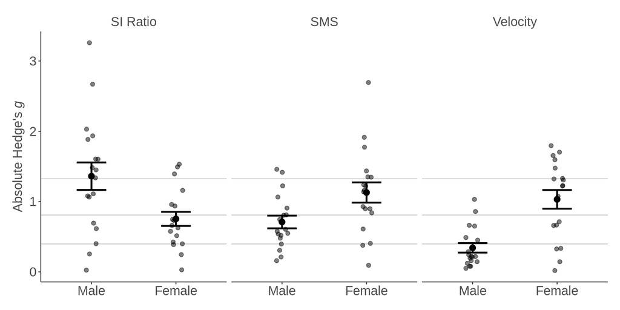

```r
# Calculate abs. ESs by cohort
SIT_diff %>%
  group_by(cohort, Sex) %>%
  summarise(g_SI_ratio = abs(effectsize::hedges_g(IZ_time ~ Condition, .data)$Hedges_g),
            g_SMS = abs(effectsize::hedges_g(SMS ~ Condition, .data)$Hedges_g),
            g_Vel_diff = abs(effectsize::hedges_g(Velocity ~ Condition, .data)$Hedges_g)) %>%
  pivot_longer(cols = c('g_SI_ratio', 'g_SMS', 'g_Vel_diff'),
               values_to = 'hedges_g', names_to = 'metric') %>%
  mutate(metric = factor(metric, levels = c('g_SI_ratio', 'g_SMS', 'g_Vel_diff'),
                           labels = c('SI Ratio', 'SMS', 'Velocity')),
         Sex = factor(Sex, levels = c('Male', 'Female'))) -> g_es_cohort

# Calculate overall ES
SIT_diff %>%
  group_by(Sex) %>%
  summarise(g_SI_ratio = abs(effectsize::hedges_g(IZ_time ~ Condition, .data)$Hedges_g),
            g_SMS = abs(effectsize::hedges_g(SMS ~ Condition, .data)$Hedges_g),
            g_Vel_diff = abs(effectsize::hedges_g(Velocity ~ Condition, .data)$Hedges_g)) %>%
  pivot_longer(cols = c('g_SI_ratio', 'g_SMS', 'g_Vel_diff'),
               values_to = 'hedges_g', names_to = 'metric') %>%
  mutate(metric = factor(metric, levels = c('g_SI_ratio', 'g_SMS', 'g_Vel_diff'),
                           labels = c('SI Ratio', 'SMS', 'Velocity')),
         Sex = factor(Sex, levels = c('Male', 'Female'))) -> g_es

# Plot
es_plot <- ggplot(g_es_cohort, aes(Sex, hedges_g)) +
                  geom_hline(yintercept = pwr.t.test(n = 100, sig.level = 0.05, power = 0.8)$d,
                             color = 'gray80') +
                  geom_hline(yintercept = pwr.t.test(n = 25, sig.level = 0.05, power = 0.8)$d,
                             color = 'gray80') +
                  geom_hline(yintercept = pwr.t.test(n = 10, sig.level = 0.05, power = 0.8)$d,
                             color = 'gray80') +
                  geom_jitter(height = 0, width = 0.08, size = 2, alpha = 0.5) +
                  stat_summary(fun = 'mean', geom = 'point', size = 3) +
                  stat_summary(fun.data = 'mean_se', geom = 'errorbar',
                               linewidth = 1, width = 0.35) +
                  ylab(expression("Absolute Hedge's"*" "*italic("g"))) +
                  facet_grid(. ~ metric) +
                  plot_theme +
                  theme(axis.title.x = element_blank(),
                  legend.position = 'none')

es_plot
```

### $\Delta$Velocity effects are driven by differences in Target trial between control and witness females (Fig. S4)

We find that the differences in $\Delta$Velocity are largely driven by changes in the Target trial.

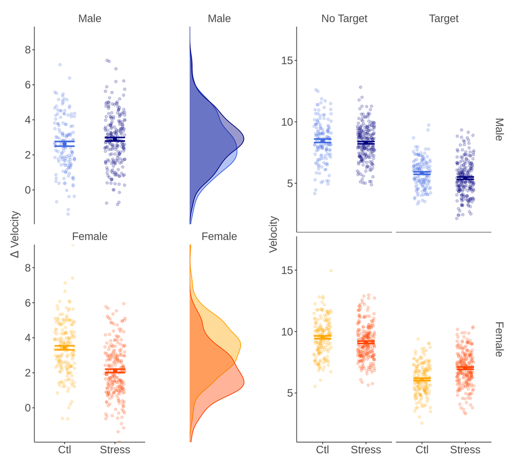

```r
point <- ggplot(SIT_diff, aes(Condition, Velocity, color = full_cond, fill = full_cond)) +
  geom_jitter(width = 0.2, alpha = 0.2, height = 0) +
  stat_summary(fun.y = 'mean', geom = 'point', size = 2) +
  stat_summary(fun.data = 'mean_se', geom = 'errorbar',
               linewidth = 1, width = 0.4) +
  scale_y_continuous(name = expression(Delta*' Velocity'), expand = c(0,0,0,0), breaks = c(0,2,4,6,8)) +
  facet_wrap(Sex ~ ., nrow = 2) +
  scale_color_manual(values = col_full) +
  plot_theme +
  theme(legend.position = 'None',
        axis.title.x = element_blank())

hist <- ggplot(SIT_diff, aes(y=Velocity, color = full_cond, fill = full_cond)) +
  geom_density(alpha = 0.4) +
  scale_x_continuous(expand = c(0,0), limits = c(0,.3),
                     breaks = c(0,0.5,1),  name = c('Density')) +
  scale_y_continuous(name = 'SI Ratio', expand = c(0,0,0,0)) +
  scale_color_manual(values = col_full) +
  scale_fill_manual(values = col_full) +
  plot_theme +
  facet_wrap(Sex ~ ., nrow = 2) + format

Vel <- plot_grid(point, hist + clean_theme(),
          ncol = 2, nrow = 1, align = 'hv', rel_widths = c(1.5,1))

Raw <- ggplot(SIT_raw, aes(Condition, Velocity, color = full_cond, fill = full_cond)) +
  geom_hline(yintercept = 1) +
  geom_jitter(width = 0.2, alpha = 0.2, height = 0) +
  stat_summary(fun.y = 'mean', geom = 'point',  size = 2) +
  stat_summary(fun.data = 'mean_se', geom = 'errorbar',
               linewidth = 1, width = 0.4) +
  scale_y_continuous(name = 'Velocity', expand = c(0,0,0.2,0)) +
  facet_grid(Sex ~ Trial_type) +
  scale_color_manual(values = col_full) +
  plot_theme +
  theme(legend.position = 'None',
        axis.title.x = element_blank())

plot_grid(Vel, Raw)
```

```r
# Delta Vel ANOVA
aov_Velocity <- aov(Velocity ~ Condition * Sex + cohort, SIT_diff)
sum_aov_Velocity <- summary(aov_Velocity)

sidak_cond_sex <- pairs(emmeans(aov_Velocity, ~ Condition | Sex), adjust = 'sidak')
sidak_sex_cond <- pairs(emmeans(aov_Velocity, ~ Sex | Condition), adjust = 'sidak')

# Velocity rmANOVAs per Sex
m_data <- SIT_raw[SIT_raw$Sex == 'Male',]
m_aov <- aov(Velocity ~ Condition * Trial_type + cohort + Error(id_full), m_data)
f_data <- SIT_raw[SIT_raw$Sex == 'Female',]
f_aov <- aov(Velocity ~ Condition * Trial_type + cohort + Error(id_full), f_data)

# Sidak
sidak_cond_tt_m <- pairs(emmeans(m_aov, ~ Condition | Trial_type), adjust = 'sidak')
sidak_tt_cond_m <- pairs(emmeans(m_aov, ~ Trial_type | Condition), adjust = 'sidak')
sidak_cond_tt_f <- pairs(emmeans(f_aov, ~ Condition | Trial_type), adjust = 'sidak')
sidak_tt_cond_f <- pairs(emmeans(f_aov, ~ Trial_type | Condition), adjust = 'sidak')
```

ANOVA: Sex * Condition ~ Delta Velocity

|  | Df | Sum Sq | Mean Sq | F value | Pr(>F) |
| --- | --- | --- | --- | --- | --- |
| **Condition** | 1 | 62.04 | 62.04 | 32.23 | 1.974e-08 |
| **Sex** | 1 | 3.311 | 3.311 | 1.72 | 0.1901 |
| **cohort** | 19 | 311.8 | 16.41 | 8.523 | 5.191e-22 |
| **Condition:Sex** | 1 | 116.6 | 116.6 | 60.57 | 2.402e-14 |
| **Residuals** | 738 | 1421 | 1.925 | NA | NA |

Sidak Post-Hoc Planned Contrasts of ANOVA

| Sex | Condition | contrast | estimate | SE | df | t.ratio | p.value |
| --- | --- | --- | --- | --- | --- | --- | --- |
| Male | . | Ctl - Stress | -0.24813 | 0.15081 | 738 | -1.64528 | 0.40136 |
| Female | . | Ctl - Stress | 1.35275 | 0.14008 | 738 | 9.65683 | 0.00000 |
| . | Ctl | Male - Female | -1.00165 | 0.16392 | 738 | -6.11077 | 0.00000 |
| . | Stress | Male - Female | 0.59923 | 0.13698 | 738 | 4.37462 | 0.00006 |

rmANOVA in Males

|  | Df | Sum Sq | Mean Sq | F value | Pr(>F) |
| --- | --- | --- | --- | --- | --- |
| **Condition** | 1 | 13.79 | 13.79 | 5.856 | 0.01605 |
| **cohort** | 17 | 285.6 | 16.8 | 7.132 | 7.262e-15 |
| **Residuals** | 338 | 796.1 | 2.355 | NA | NA |
| **Trial_type** | 1 | 1388 | 1388 | 1177 | 8.918e-115 |
| **Condition:Trial_type** | 1 | 2.944 | 2.944 | 2.498 | 0.1149 |
| **Residuals** | 355 | 418.4 | 1.179 | NA | NA |

Sidak Post-Hoc Planned Contrasts in Males: Ctl vs Stress

| contrast | Trial_type | estimate | SE | df | t.ratio | p.value |
| --- | --- | --- | --- | --- | --- | --- |
| Ctl - Stress | No Target | 0.0821 | 0.14475 | 611.3918 | 0.56715 | 0.57082 |
| Ctl - Stress | Target | 0.3448 | 0.14475 | 611.3918 | 2.38197 | 0.01753 |

Sidak Post-Hoc Planned Contrasts in Males: NT vs T

| contrast | Condition | estimate | SE | df | t.ratio | p.value |
| --- | --- | --- | --- | --- | --- | --- |
| No Target - Target | Ctl | 2.62909 | 0.12929 | 355 | 20.33418 | 0 |
| No Target - Target | Stress | 2.89179 | 0.10446 | 355 | 27.68252 | 0 |

rmANOVA in Females

|  | Df | Sum Sq | Mean Sq | F value | Pr(>F) |
| --- | --- | --- | --- | --- | --- |
| **Condition** | 1 | 12.33 | 12.33 | 5.254 | 0.02244 |
| **cohort** | 17 | 243.8 | 14.34 | 6.108 | 1.297e-12 |
| **Residuals** | 385 | 903.8 | 2.348 | NA | NA |
| **Trial_type** | 1 | 1447 | 1447 | 1295 | 8.598e-128 |
| **Condition:Trial_type** | 1 | 85.55 | 85.55 | 76.56 | 5.955e-17 |
| **Residuals** | 402 | 449.2 | 1.117 | NA | NA |

Sidak Post-Hoc Planned Contrasts in Females: Ctl vs Stress

| contrast | Trial_type | estimate | SE | df | t.ratio | p.value |
| --- | --- | --- | --- | --- | --- | --- |
| Ctl - Stress | No Target | 0.42603 | 0.13287 | 686.4548 | 3.20640 | 0.00141 |
| Ctl - Stress | Target | -0.88820 | 0.13287 | 686.4548 | -6.68479 | 0.00000 |

Sidak Post-Hoc Planned Contrasts in Females: NT vs T

| contrast | Condition | estimate | SE | df | t.ratio | p.value |
| --- | --- | --- | --- | --- | --- | --- |
| No Target - Target | Ctl | 3.42486 | 0.11333 | 402 | 30.21974 | 0 |
| No Target - Target | Stress | 2.11063 | 0.09857 | 402 | 21.41164 | 0 |